# case.intro_to_eda.coding

```python
import numpy                 as np
import pandas                as pd
import matplotlib.pyplot     as plt
import seaborn               as sns
import folium  #needed for interactive map
from folium.plugins import HeatMap
%matplotlib inline
sns.set()
```

```python
pip install matplotlib
```

[output not shown]

```python
pip install seaborn
```

[output not shown]

```python
pip install folium
```

```
     |████████████████████████████████| 95 kB 2.1 MB/s eta 0:00:01
```

# What features determine the price of an Airbnb rental?

## Some basic data exploration

We begin by loading the data and looking at its basic shape:

```python
listings = pd.read_csv('data/airbnb_nyc.csv', delimiter=',')
listings.shape
```

```
(30179, 81)
```

We display the basic listings data:

```python
pd.options.display.max_columns = 100
listings.head(3)
```

|  | id | name | summary | description | experiences_offered | neighborhood_overview | transit | house_rules | host_id | host_since | host_response_time | host_response_rate | host_is_superhost | host_listings_count | host_identity_verified | street | neighbourhood | latitude | longitude | property_type | room_type | accommodates | bathrooms | bedrooms | beds | bed_type | amenities | price | guests_included | … |
| --- | --- | --- | --- | --- | --- | --- | --- | --- | --- | --- | --- | --- | --- | --- | --- | --- | --- | --- | --- | --- | --- | --- | --- | --- | --- | --- | --- | --- | --- | --- |
| 0 | 2539 | Clean & quiet apt home by the park | Renovated apt home in elevator building. | Renovated apt home in elevator building. Spaci... | none | Close to Prospect Park and Historic Ditmas Park | Very close to F and G trains and Express bus i... | -The security and comfort of all our guests is... | 2787 | 39698.0 | within an hour | 1.0 | 0.0 | 6.0 | 1.0 | Brooklyn , NY, United States | Brooklyn | 40.64749 | -73.97237 | Apartment | Private room | 2 | 1.0 | 1 | 1 | Real Bed | {TV,"Cable TV",Internet,Wifi,"Wheelchair acces... | 149 | 1 | … |
| 1 | 3647 | THE VILLAGE OF HARLEM....NEW YORK ! | NaN | WELCOME TO OUR INTERNATIONAL URBAN COMMUNITY T... | none | NaN | NaN | Upon arrival please have a legibile copy of yo... | 4632 | 39777.0 | within a day | 1.0 | 0.0 | 1.0 | 1.0 | New York, NY, United States | Harlem | 40.80902 | -73.94190 | Apartment | Private room | 2 | 1.0 | 1 | 1 | Pull-out Sofa | {"Cable TV",Internet,Wifi,"Air conditioning",K... | 150 | 2 | … |
| 2 | 7750 | Huge 2 BR Upper East Cental Park | NaN | Large Furnished 2BR one block to Central Park... | none | NaN | NaN | NaN | 17985 | 39953.0 | within a day | 1.0 | 0.0 | 2.0 | 1.0 | New York, NY, United States | Harlem | 40.79685 | -73.94872 | Apartment | Entire home/apt | 4 | 1.0 | 2 | 2 | Real Bed | {TV,"Cable TV",Internet,Wifi,"Air conditioning... | 190 | 1 | … |

### Plotting the marginal distributions of key quantities of interest

As you have seen in the Python cases, it is good to first develop an idea of how the values of a few key quantities of interest are distributed. We always start investigating by gaining an overhead view of various parameters in our data. Let's start by doing so for some numeric variables, such as `price`, `bedrooms`, `bathrooms`, `number_of_reviews`.

### Example 1

Use the [describe()](https://pandas.pydata.org/pandas-docs/stable/reference/api/pandas.DataFrame.describe.html) command to compute some important summary statistics for the above variables.

**Answer.** One possible solution is given below:

```python
listings[['price','bedrooms','bathrooms','number_of_reviews']].describe()
```

|  | price | bedrooms | bathrooms | number_of_reviews |
| --- | --- | --- | --- | --- |
| count | 30179.000000 | 30179.000000 | 30179.000000 | 30179.000000 |
| mean | 132.949965 | 1.265516 | 1.151595 | 4.459889 |
| std | 93.151824 | 0.614659 | 0.422225 | 5.265633 |
| min | 0.000000 | 1.000000 | 0.500000 | 0.000000 |
| 25% | 65.000000 | 1.000000 | 1.000000 | 0.000000 |
| 50% | 100.000000 | 1.000000 | 1.000000 | 2.000000 |
| 75% | 175.000000 | 1.000000 | 1.000000 | 7.000000 |
| max | 500.000000 | 11.000000 | 7.500000 | 20.000000 |

```python
listings[['price','bedrooms','bathrooms','number_of_reviews']].quantile([0.9,0.95,0.99])
```

|  | price | bedrooms | bathrooms | number_of_reviews |
| --- | --- | --- | --- | --- |
| 0.90 | 250.0 | 2.0 | 2.0 | 13.0 |
| 0.95 | 325.0 | 3.0 | 2.0 | 16.0 |
| 0.99 | 450.0 | 4.0 | 2.5 | 20.0 |

### Exercise 1

Plot the histograms of the above variables.

**Answer.** This is one possible answer:

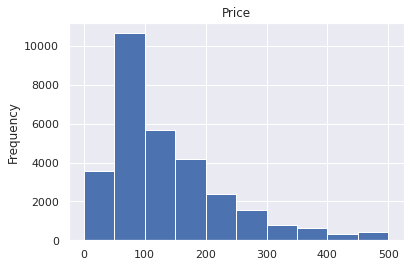

```python
listings["price"].plot.hist(title="Price")
```

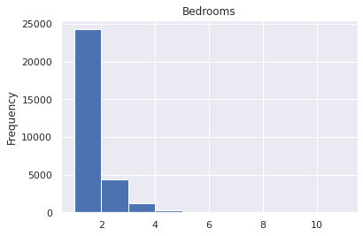

```python
listings["bedrooms"].plot.hist(title="Bedrooms")
```

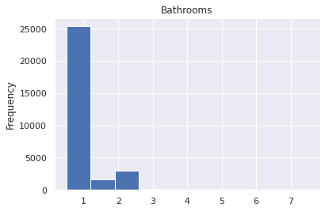

```python
listings["bathrooms"].plot.hist(title="Bathrooms")
```

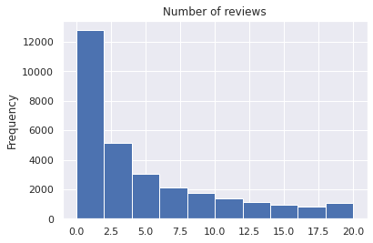

```python
listings["number_of_reviews"].plot.hist(title="Number of reviews")
```

## Inspecting price against variables of interest

Using `seaborn`, we can create box plots in which the data are grouped by a second column. For instance:

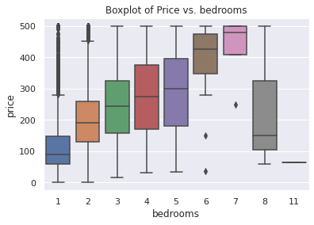

```python
sns.boxplot(x = "bedrooms", y='price', data = listings)
plt.title("Boxplot of Price vs. bedrooms")
```

### Exercise 2

Create box plots of `price` vs. `bathrooms`, `price` vs. `number_of_reviews`, and `price` vs. `review_scores_cleanliness`.

**Answer.** One possible solution is given below:

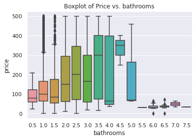

```python
sns.boxplot(x = "bathrooms", y='price', data = listings)
plt.title("Boxplot of Price vs. bathrooms")
```

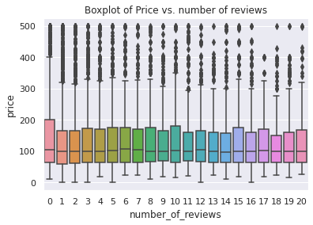

```python
sns.boxplot(x = "number_of_reviews", y='price', data = listings)
plt.title("Boxplot of Price vs. number of reviews")
```

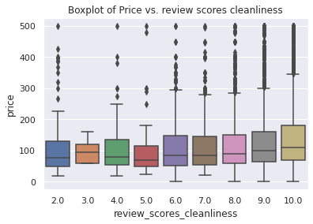

```python
sns.boxplot(x = "review_scores_cleanliness", y='price', data = listings)
plt.title("Boxplot of Price vs. review scores cleanliness")
```

## Investigating correlations

To calculate correlation coefficients, we use [**`.corr()`**](https://pandas.pydata.org/docs/reference/api/pandas.DataFrame.corr.html) from `pandas`. For instance, to find the correlation $r$ between `price` and `bedrooms`, we can run this line:

```python
listings[["price", "bedrooms"]].corr()
```

|  | price | bedrooms |
| --- | --- | --- |
| price | 1.000000 | 0.454539 |
| bedrooms | 0.454539 | 1.000000 |

This gives you a **correlation matrix** that tells you that

$$ r_{price,price} = 1\\ r_{price,bedrooms} = r_{bedrooms,price} = 0.454539 $$

This would be the correlation matrix for all the variables in the DataFrame:

```python
corrm = listings.corr()
corrm
```

|  | id | host_id | host_since | host_response_rate | host_is_superhost | host_listings_count | host_identity_verified | latitude | longitude | accommodates | bathrooms | bedrooms | beds | price | guests_included | extra_people | minimum_nights | has_availability | availability_30 | availability_60 | availability_90 | availability_365 | number_of_reviews | number_of_reviews_ltm | review_scores_rating | review_scores_accuracy | review_scores_cleanliness | review_scores_checkin | review_scores_communication | … |
| --- | --- | --- | --- | --- | --- | --- | --- | --- | --- | --- | --- | --- | --- | --- | --- | --- | --- | --- | --- | --- | --- | --- | --- | --- | --- | --- | --- | --- | --- | --- |
| id | 1.000000 | 0.567767 | 0.530654 | 0.103325 | 0.062122 | 0.071475 | -0.351613 | -0.005784 | 0.109353 | 0.095344 | 0.041364 | 0.052900 | 0.081639 | 0.027533 | 0.073860 | 0.015423 | 0.000090 | NaN | 0.275434 | 0.310207 | 0.323030 | 0.241093 | -0.099074 | 0.281097 | 0.005712 | -0.008610 | 0.051732 | -0.026479 | -0.046465 | … |
| host_id | 0.567767 | 1.000000 | 0.905404 | 0.031051 | 0.002383 | 0.036721 | -0.471233 | 0.025581 | 0.128454 | 0.103469 | 0.058319 | 0.055659 | 0.114607 | 0.028931 | 0.093609 | 0.030244 | 0.000424 | NaN | 0.293828 | 0.333110 | 0.350964 | 0.299765 | -0.031790 | 0.191829 | -0.082189 | -0.089129 | -0.001015 | -0.084407 | -0.105143 | … |
| host_since | 0.530654 | 0.905404 | 1.000000 | 0.029362 | -0.005315 | 0.056799 | -0.460919 | 0.043202 | 0.133671 | 0.059946 | 0.037348 | 0.021578 | 0.082001 | -0.009671 | 0.051555 | 0.000478 | -0.003294 | NaN | 0.239441 | 0.273200 | 0.291389 | 0.242459 | -0.052206 | 0.162810 | -0.090009 | -0.087586 | -0.022991 | -0.082780 | -0.104489 | … |
| host_response_rate | 0.103325 | 0.031051 | 0.029362 | 1.000000 | 0.133280 | 0.071515 | -0.021462 | -0.000586 | 0.018393 | 0.067337 | 0.041781 | 0.037776 | 0.046493 | 0.034280 | 0.048346 | 0.012583 | -0.002015 | NaN | -0.096749 | -0.092871 | -0.090221 | -0.043331 | 0.101951 | 0.144492 | 0.050464 | 0.047434 | 0.073322 | 0.056361 | 0.064596 | … |
| host_is_superhost | 0.062122 | 0.002383 | -0.005315 | 0.133280 | 1.000000 | -0.021501 | -0.000838 | -0.017228 | 0.064378 | 0.026010 | -0.003154 | 0.022136 | 0.020835 | -0.016325 | 0.038419 | 0.065973 | 0.048219 | NaN | 0.034459 | 0.051846 | 0.062296 | 0.084598 | 0.246618 | 0.278945 | 0.113434 | 0.096486 | 0.118412 | 0.079193 | 0.081936 | … |
| ... | ... | ... | ... | ... | ... | ... | ... | ... | ... | ... | ... | ... | ... | ... | ... | ... | ... | ... | ... | ... | ... | ... | ... | ... | ... | ... | ... | ... | ... | … |
| secure | -0.062950 | -0.051488 | -0.033657 | -0.009455 | 0.048612 | -0.024161 | 0.030771 | -0.008190 | 0.009031 | 0.028119 | 0.059877 | 0.017632 | 0.033655 | 0.019678 | 0.018293 | 0.040477 | -0.001978 | NaN | -0.004286 | -0.008602 | -0.008602 | 0.000601 | 0.035585 | 0.006080 | 0.002493 | -0.004908 | 0.009630 | -0.004040 | -0.015595 | … |
| self_check_in | 0.143029 | 0.039264 | 0.027736 | 0.112369 | 0.123705 | 0.163752 | -0.024953 | -0.063903 | 0.024616 | 0.145485 | 0.068656 | 0.072891 | 0.116476 | 0.108914 | 0.132165 | 0.058295 | 0.056421 | NaN | 0.063527 | 0.085539 | 0.097287 | 0.136773 | 0.190795 | 0.235374 | 0.038681 | 0.035558 | 0.057665 | 0.033440 | 0.020694 | … |
| smoking_allowed | 0.002802 | 0.000612 | 0.017108 | -0.043715 | -0.025842 | 0.000765 | -0.010547 | -0.012216 | 0.046009 | -0.049053 | -0.006478 | -0.032529 | -0.044281 | -0.054131 | -0.040256 | -0.011141 | -0.037168 | NaN | 0.012362 | 0.005242 | 0.002687 | -0.015533 | -0.026330 | -0.028410 | -0.064528 | -0.049196 | -0.087029 | -0.039835 | -0.028504 | … |
| accessible | -0.074635 | -0.033810 | -0.038432 | 0.019444 | 0.042958 | -0.029330 | 0.041090 | 0.028615 | 0.031948 | 0.048473 | 0.004377 | 0.015918 | 0.037702 | 0.038301 | 0.052828 | 0.056749 | -0.011586 | NaN | 0.011443 | 0.012991 | 0.017862 | 0.026013 | 0.079881 | 0.046079 | 0.013246 | 0.008478 | 0.019824 | 0.007555 | 0.020536 | … |
| event_suitable | 0.026211 | 0.014483 | 0.020046 | -0.020509 | -0.011303 | -0.001697 | -0.001946 | -0.017084 | 0.021722 | 0.053568 | 0.030889 | 0.031981 | 0.035118 | 0.012606 | 0.007802 | -0.011105 | 0.008347 | NaN | 0.013500 | 0.010338 | 0.011253 | 0.016780 | -0.018761 | -0.019210 | -0.031867 | -0.038301 | -0.042622 | -0.029093 | -0.020973 | … |

65 rows × 65 columns

### Exercise 3

Write code to print the columns which are positively correlated with `price`, from most positive to least positive. Similarly, print the columns which are negatively correlated, from most negative to least negative.

**Answer.** Shown below:

```python
pos_cor = corrm['price'] >0
corrm['price'][pos_cor].sort_values(ascending = False).to_frame()
```

|  | price |
| --- | --- |
| price | 1.000000 |
| accommodates | 0.571541 |
| bedrooms | 0.454539 |
| beds | 0.421355 |
| guests_included | 0.321970 |
| tv | 0.271563 |
| elevator | 0.229610 |
| calculated_host_listings_count_entire_homes | 0.218890 |
| white_goods | 0.214283 |
| gym | 0.209892 |
| child_friendly | 0.206189 |
| air_conditioning | 0.196582 |
| host_listings_count | 0.194891 |
| calculated_host_listings_count | 0.185098 |
| bathrooms | 0.163276 |
| private_entrance | 0.146453 |
| review_scores_location | 0.140308 |
| coffee_machine | 0.133457 |
| availability_365 | 0.118864 |
| bbq | 0.110258 |
| self_check_in | 0.108914 |
| bed_linen | 0.105295 |
| availability_60 | 0.099858 |
| long_term_stays | 0.096381 |
| review_scores_cleanliness | 0.095329 |
| availability_90 | 0.093483 |
| cooking_basics | 0.087954 |
| latitude | 0.079542 |
| balcony | 0.079413 |
| extra_people | 0.075439 |
| availability_30 | 0.075208 |
| pets_allowed | 0.070507 |
| hot_tub_sauna_or_pool | 0.064996 |
| review_scores_rating | 0.064228 |
| reviews_per_month | 0.063172 |
| check_in_24h | 0.053180 |
| minimum_nights | 0.048627 |
| outdoor_space | 0.046216 |
| accessible | 0.038301 |
| host_response_rate | 0.034280 |
| review_scores_accuracy | 0.033125 |
| host_id | 0.028931 |
| high_end_electronics | 0.027578 |
| id | 0.027533 |
| instant_bookable | 0.024415 |
| internet | 0.024220 |
| secure | 0.019678 |
| review_scores_communication | 0.017169 |
| review_scores_checkin | 0.014043 |
| event_suitable | 0.012606 |
| breakfast | 0.007514 |
| nature_and_views | 0.000173 |

```python
neg_cor = corrm['price'] <0
corrm['price'][neg_cor].sort_values(ascending = True).to_frame()
```

|  | price |
| --- | --- |
| longitude | -0.294196 |
| calculated_host_listings_count_private_rooms | -0.127504 |
| calculated_host_listings_count_shared_rooms | -0.101389 |
| smoking_allowed | -0.054131 |
| host_greeting | -0.051356 |
| number_of_reviews | -0.029229 |
| host_identity_verified | -0.022861 |
| parking | -0.019383 |
| host_is_superhost | -0.016325 |
| number_of_reviews_ltm | -0.011481 |
| host_since | -0.009671 |
| review_scores_value | -0.005942 |

## Location, location, location!

Let's create an interactive map of New York. This can be easily done with the `folium` package:

```python
folium_map = folium.Map()
folium_map
```

Make this Notebook Trusted to load map: File -> Trust Notebook

[interactive chart not shown]

This is certainly a nice map, but it is not a map of New York yet. We know that New York's coordinates are latitude 40.738 (Northern hemisphere) and longitude -73.98 (Western hemisphere), so let's set that as the center of our map:

```python
ny_coords = [40.738, -73.98] # lat, long
folium_map = folium.Map(location=ny_coords)
folium_map
```

Make this Notebook Trusted to load map: File -> Trust Notebook

[interactive chart not shown]

This looks much better. We can set a default zoom that gives a closer view of the city:

```python
ny_coords = [40.738, -73.98] # lat, long
folium_map = folium.Map(location=ny_coords, zoom_start=13)
folium_map
```

Make this Notebook Trusted to load map: File -> Trust Notebook

[interactive chart not shown]

We can also change the title (the default is `OpenStreetMap`):

```python
ny_coords = [40.738, -73.98] # lat, long
folium_map = folium.Map(location=ny_coords, zoom_start=13, tiles="OpenStreetMap")
folium_map
```

Make this Notebook Trusted to load map: File -> Trust Notebook

[interactive chart not shown]

### Exercise 4 (optional)

There are other styles available for the `tiles` argument:

- `Stamen Toner`
- `Stamen Terrain`
- `Stamen Watercolor`
- `CartoDB positron`
- `CartoDB dark_matter`

Experiment with each one of these styles and take a screenshot of your favorite one. Then share it with the class.

### Using heat maps to understand the price distribution with location

Next, we create a heat map of the price of apartments in NYC. This will give us a sense of where the important locations are. First, the canvas:

```python
folium_hmap = folium.Map(location=ny_coords, zoom_start=13, tiles="OpenStreetMap")
```

Now we prepare the data. `folium` needs a list in which each element contains the `latitude`, the `longitude`, and the `price` of the listing. We can use Python's handy [**`zip()`**](https://www.w3schools.com/python/ref_func_zip.asp) function, which takes two iterables and matches their elements one-by-one pairwise, like this:

[figure not shown]

**Note:** In order to inspect the elements inside a `zip` object, we first need to convert it into a list.

```python
my_zip = zip(listings['latitude'], listings['longitude'], listings['price'])
list_of_my_zip = list(my_zip)
list_of_my_zip[0:15]
```

```
[(40.64749, -73.97237, 149),
 (40.80902, -73.9419, 150),
 (40.79685, -73.94872, 190),
 (40.65599, -73.97519, 60),
 (40.86754, -73.92639, 80),
 (40.63702, -73.96327, 150),
 (40.66278, -73.97966, 120),
 (40.65944, -73.96238, 150),
 (40.68554, -73.9409, 115),
 (40.73961, -73.98074, 200),
 (40.72004, -73.99104, 110),
 (40.6734299999999, -73.98338, 225),
 (40.65401, -73.96323, 130),
 (40.72912, -73.98057, 50),
 (40.68634, -73.966, 98)]
```

The next step is to create a `HeatMap` layer with the data:

```python
hm_layer = HeatMap(list_of_my_zip,
                   # These are parameters that we tweak manually to adjust color
                   # See folium docs for more information
                   min_opacity=0.2,
                   radius=8,
                   blur=6,
                 )
```

We can finally add this layer to our map and see the result:

```python
folium_hmap.add_child(hm_layer)
folium_hmap
```

Make this Notebook Trusted to load map: File -> Trust Notebook

[interactive chart not shown]

Let's save the map as HTML, so that we can share it later with people who don't have Jupyter in their computers. As HTML files, Folium maps can be visualized using any modern browser.

```python
folium_hmap.save("hmap.html")
```

To test that everything worked correctly, go to your folder and look for the `hmap.html` file. Then open it with your browser.

### Exercise 5 (optional)

Make a heat map using `folium` like the one we just made, only this time make the temperature of the map dependent on `review_score_rating` rather than on `price`.

**Hint:** You will need to remove null values from your DataFrame. To avoid discarding rows that contain useful data for the analyses that come after this exercise, don't overwrite `listings` - rather, create a new DataFrame that does not contain nulls and make your map with that.

**Answer.** Shown below:

```python
folium_hmap = folium.Map(location=[40.738, -73.98],
                        zoom_start=13,
                        tiles="OpenStreetMap")

listings_no_nans = listings.dropna()
hm_wide = HeatMap( list(zip(listings_no_nans['latitude'], listings_no_nans['longitude'], listings_no_nans['review_scores_rating'])),
                   min_opacity=0.2,
                   radius=8, blur=6,
                   max_zoom=15,
                 )

folium_hmap.add_child(hm_wide)
```

Make this Notebook Trusted to load map: File -> Trust Notebook

[interactive chart not shown]

When looking at the list of correlations, `parking` stood out as having a surprisingly negative correlation with price. We've seen that location has a strong influence on price; let's see if it can help explain the negative correlation exhibited by `parking`.

### Example 2

Write code here to plot the first 1,000 locations on the map where parking is available in blue color, and the first 1000 locations where parking is not available in red color.

**Hint:** You can use the commands `color = "blue"` and `color = "red"` respectively.

**Answer.** One possible solution is given below:

```python
lat_log_parking_yes = listings.loc[ listings['parking']==1.0, ["latitude","longitude" ] ]
lat_log_parking_no = listings.loc[ listings['parking']==-1.0, ["latitude","longitude" ] ]
folium_map = folium.Map(location=[40.738, -73.98],
                        zoom_start=13,
                        tiles="OpenStreetMap")
for i in range(1000):
    marker = folium.CircleMarker(location=[lat_log_parking_yes["latitude"].iloc[i],lat_log_parking_yes["longitude"].iloc[i]],radius=5,color="blue",fill=True)
    marker.add_to(folium_map)

for i in range(1000):
    marker = folium.CircleMarker(location=[lat_log_parking_no["latitude"].iloc[i],lat_log_parking_no["longitude"].iloc[i]],radius=5,color="red",fill=True)
    marker.add_to(folium_map)

folium_map
```

Make this Notebook Trusted to load map: File -> Trust Notebook

[interactive chart not shown]

## Interaction effects

Let's find the correlation between `price` and `parking` for each `neighborhood`. This is easily done with the `.groupby()` method:

```python
cbn = listings.groupby("neighbourhood")[["price", "parking"]].corr()
cbn
```

| neighbourhood |  | price | parking |
| --- | --- | --- | --- |
| Allerton | price | 1.000000 | 0.188982 |
|  | parking | 0.188982 | 1.000000 |
| Alphabet City | price | 1.000000 | 0.107394 |
|  | parking | 0.107394 | 1.000000 |
| Annadale | price | 1.000000 | 1.000000 |
| ... | ... | ... | ... |
| Woodhaven | parking | 0.143018 | 1.000000 |
| Woodlawn | price | 1.000000 | 1.000000 |
|  | parking | 1.000000 | 1.000000 |
| Woodside | price | 1.000000 | -0.170445 |
|  | parking | -0.170445 | 1.000000 |

372 rows × 2 columns

Let's filter out redundant information:

```python
cbn = cbn.reset_index()
cbn = cbn.drop(columns=["parking"])
cbn.columns = ["neighbourhood", "variable", "r_parking_price"]
cbn = cbn[cbn["variable"]=="parking"]
cbn = cbn.drop(columns=["variable"])
cbn
```

|  | neighbourhood | r_parking_price |
| --- | --- | --- |
| 1 | Allerton | 0.188982 |
| 3 | Alphabet City | 0.107394 |
| 5 | Annadale | 1.000000 |
| 7 | Astoria | 0.086911 |
| 9 | Bath Beach | -1.000000 |
| ... | ... | ... |
| 363 | Williamsburg | 0.075120 |
| 365 | Windsor Terrace | 0.120691 |
| 367 | Woodhaven | 0.143018 |
| 369 | Woodlawn | 1.000000 |
| 371 | Woodside | -0.170445 |

186 rows × 2 columns

### Exercise 6

Find out how many neighborhoods present a strongly negative, mildly negative, mildly positive, and strongly positive correlation between `price` and `parking`. Specifically, we want to know how many neighborhoods show a correlation between -1 and -0.5, between -0.5 and 0, between 0 and 0.5 and between 0.5 and 1.

**Hint:** For this, you can use the [`.plot.hist()`](https://pandas.pydata.org/pandas-docs/stable/reference/api/pandas.DataFrame.plot.hist.html) method again, this time specifying the bins you want the data to be split into.

**Answer**. One possible answer is below:

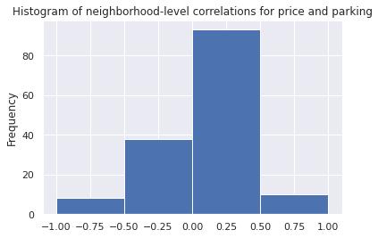

```python
cbn["r_parking_price"].plot.hist(
    bins=[-1, -0.5, 0, 0.5, 1],
    title="Histogram of neighborhood-level correlations for price and parking"
    )
```

### Exercise 7

Create four density plots that overlay the distribution of price for parking and non-parking, for each of the following neighborhoods: `St. George`, `Greenwood Heights`, `Rego Park`, and `Brooklyn Navy Yard`.

**Hint:** Use the [`sns.kdeplot()`](https://seaborn.pydata.org/generated/seaborn.kdeplot.html) function and the `hue` argument.

**Answer**. One possible answer is below:

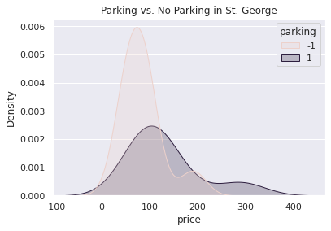

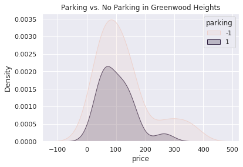

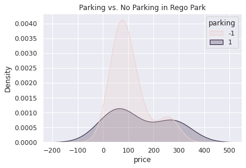

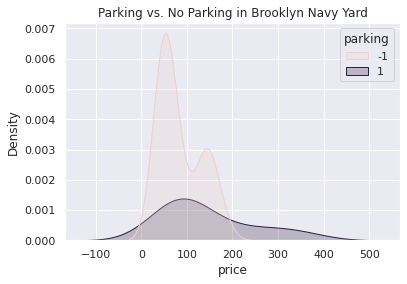

```python
neigh_to_look = ['St. George','Greenwood Heights','Rego Park','Brooklyn Navy Yard']

for neigh in neigh_to_look:
    data_plot = listings[listings['neighbourhood'] == neigh]
    sns.kdeplot(data=data_plot,x='price', hue='parking', shade = True, label="Parking")
    plt.title("Parking vs. No Parking in " + neigh)
    plt.show()
```

### Exercise 8

Plot average property price across all locations as a time series. The relevant dataset is `data/scal.csv`.

**Hint:** Use the `pd.to_datetime()` function with the `format="%Y%m%d"` argument to process the dates.

**Answer**. One possible answer is below:

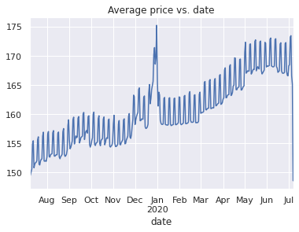

```python
scal = pd.read_csv("data/scal.csv")
scal["date"] = pd.to_datetime(scal["date"], format="%Y%m%d")
scal.groupby("date")["price"].mean().plot(title="Average price vs. date")
```

## Attribution

"New York", Inside Airbnb, [Public Domain](http://creativecommons.org/publicdomain/zero/1.0/), http://insideairbnb.com/get-the-data.html